# R Notebook

# call function fore k value

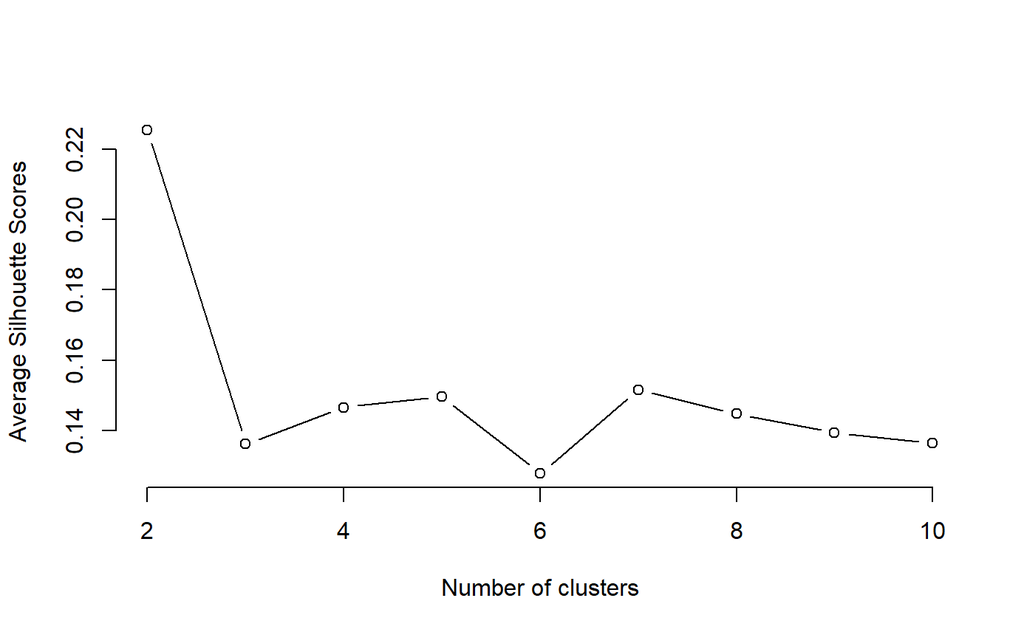

```r
avg_sil <- sapply(k, silhouette_score)
plot(k, type='b', avg_sil, xlab='Number of clusters', ylab='Average Silhouette Scores', frame=FALSE)
```

The Silhouette method graph shows how the average silhouette coefficient changes as the number of clusters (k) increases. The optimal number of clusters is often chosen as the value of k that corresponds to the highest average silhouette coefficient. However, it is important to note that the highest average silhouette coefficient may not necessarily indicate the best clustering solution. For example, if the average silhouette coefficient is high for all values of k, it may suggest that the data is not well-clustered at all.

# Finding the optimal number of clusters applying Silhouette method

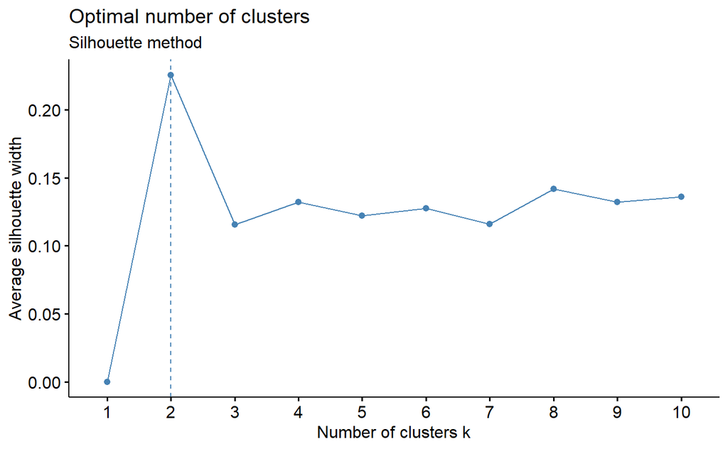

```r
fviz_nbclust(data_clustring, kmeans, method = "silhouette")+
  labs(subtitle = "Silhouette method")
```